# CMSC320 Final Project

Pratyush Sahay

May 17, 2018

### **Introduction**

Have you ever wondered which factors of a student’s life and their individual engagement in class effect how well they perform? I will be using an educational dataset of students’ academic performance, which was collected from a learning management system called Kalboard 360 (more information can be found here: http://test3.aimstyle.com/AboutUs.aspx), to answer this question. The steps required to answer this question include tidying the dataset, exploratory data analysis, hypothesis testing, modelling, and model selection.

I will be using R in RStudio to complete my analysis and modelling. R download link: https://www.r-project.org/ RStudio download link: https://www.rstudio.com/products/rstudio/

This project requires the following libraries which can be downloaded in the RStudio IDE:

- tidyverse
- data.table
- dplyr
- ISLR
- broom
- ggplot2
- tree
- cvTools
- nnet
- caTools
- randomForest
- caret
- e1071

Information about each of the packages can be found in the RStudio IDE help tab.

Finally, you can download the Students’ Academic Performance Dataset from: https://www.kaggle.com/aljarah/xAPI-Edu-Data

### **1. Load and View Data**

After downloading the dataset, we must load it into R as a dataframe that we can manipulate by performing various functions. We do so by using the read_csv() command and putting the results into the variable named “df”. We must also load all of the libraries needed.

```r
knitr::opts_chunk$set(echo = TRUE, message=FALSE, warning=FALSE)
library(tidyverse)
library(data.table)
library(dplyr)
library(ISLR)
library(broom)
library(ggplot2)
library(tree)
library(cvTools)
library(nnet)
library(caTools)
library(randomForest)
library(caret)
library(e1071)
df <- read_csv("performance.csv")
```

- gender
  - Student’s gender
- raisedhands
  - How many times the student raises his/her hand in class
- Class
  - Classification based on grade. Put into three numeric intervals (H = 90-100, M = 70-89, L = 0-69)
- etc.

In order to get an understanding of what each of the columns represent, I encourage you to go to https://www.kaggle.com/aljarah/xAPI-Edu-Data and scroll down to the “Attributes” section in the “Overview” tab. This section gives a thorough explanation of what each column represents.

```r
head(df)
```

```
## # A tibble: 6 x 17
##   gender NationalITy PlaceofBirth StageID GradeID SectionID Topic Semester
##   <chr>  <chr>       <chr>        <chr>   <chr>   <chr>     <chr> <chr>
## 1 M      KW          KuwaIT       Middle~ G-07    A         Math  F
## 2 F      KW          KuwaIT       Middle~ G-08    A         Math  F
## 3 M      KW          KuwaIT       Middle~ G-07    B         IT    F
## 4 F      KW          KuwaIT       Middle~ G-08    A         Arab~ F
## 5 F      KW          KuwaIT       HighSc~ G-12    A         Engl~ F
## 6 F      KW          KuwaIT       HighSc~ G-12    A         Engl~ F
## # ... with 9 more variables: Relation <chr>, raisedhands <int>,
## #   VisITedResources <int>, AnnouncementsView <int>, Discussion <int>,
## #   ParentAnsweringSurvey <chr>, ParentschoolSatisfaction <chr>,
## #   StudentAbsenceDays <chr>, Class <chr>
```

### **2. Tidying Data**

Now that we know what our dataset looks like, we can begin cleaning it up so it is more accessible and easier to maneuver. We’ll start by checking to see if there are any data points that are missing from the dataset. We will sum all of the data points that were represented as “NA” (missing) in the dataframe.

```r
sapply(df, function(x) sum(is.na(x)))
```

```
##                   gender              NationalITy             PlaceofBirth
##                        0                        0                        0
##                  StageID                  GradeID                SectionID
##                        0                        0                        0
##                    Topic                 Semester                 Relation
##                        0                        0                        0
##              raisedhands         VisITedResources        AnnouncementsView
##                        0                        0                        0
##               Discussion    ParentAnsweringSurvey ParentschoolSatisfaction
##                        0                        0                        0
##       StudentAbsenceDays                    Class
##                        0                        0
```

As we can see from the output, there are no missing data points! This is good news for us since we don’t need to remove any observations or plug in “random” or averaged data into the missing datapoints.

#### **2.1 Factoring Data**

Next, we will factor our categorical attributes, which are currently stored as characters. The reason for this will become clear later in the tutorial. For now, it would be beneficial to brush up on categorical versus numerical variables which you can do here: http://www.dummies.com/education/math/statistics/types-of-statistical-data-numerical-categorical-and-ordinal/

```r
### Factor Columns
col_names <- c("gender","NationalITy","PlaceofBirth","StageID","SectionID","Topic","Semester","Relation","ParentAnsweringSurvey","ParentschoolSatisfaction","StudentAbsenceDays","Class")
df[col_names] <- lapply(df[col_names] , factor)
```

#### **2.2 Renaming and Removing**

The next step is to rename the columns in the dataset so they are easier to access and understand. We can also remove column 14, ParentAnsweringSurvey, as it is not very relevant to our research question.

```r
### Rename Columns
colnames(df)[2] <- "Nationality"
colnames(df)[5] <- "Year"
colnames(df)[7] <- "Subject"
colnames(df)[11] <- "Resource"
colnames(df)[15] <- "Satisfaction"
colnames(df)[17] <- "GradeRange"

### Remove Unimportant Columns
df <- df[,-14]
```

This concludes the data tidying process. We were pretty lucky with this particular dataset, as it did not require much tidying. In actuality, many more problems are likely to arise, such as missing data points, unclean formatting, and just messy data. Many more tidying operations and processes can be found here: https://cran.r-project.org/web/packages/tidyr/vignettes/tidy-data.html

### **3. Exploratory Data Analysis**

Now that our data is clean, we can start learning more about it by using exploratory data analysis, which is the intermediate step to performing statistical or machine learning processes. The overall goal of this step is to learn about the data through visuals and statistics so we can determine what exactly the data is “telling” us about student’s academic performances.

#### **3.1 Histograms**

The variable that measures how well a student is performing would be the GradeRange variable. We will start by analyzing how some of the other variables influence the grade a student receives, if at all. Below is a histogram of the grade a student received, categorized by the parent primarily responsible for the student (Relation variable). We will be using the ggplot function to do so. Read more about the ggplot2 package here: http://ggplot2.tidyverse.org/

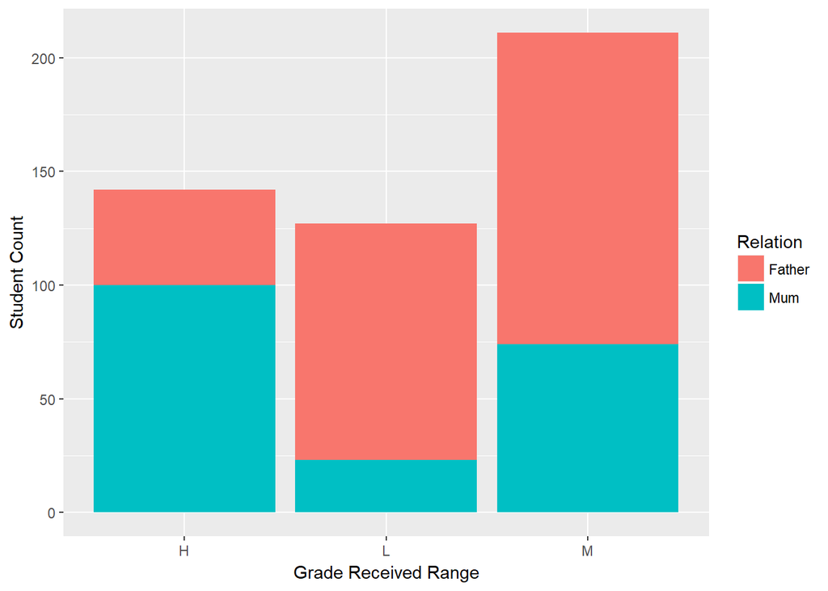

```r
ggplot(data = df, aes(x = GradeRange, fill = Relation)) + geom_bar() +
    labs(x = "Grade Received Range", y = "Student Count")
```

The histogram gives us some interesting information. It seems that for this sample of data, students who are primarily taken care of by their mother tend to be in the high and medium grade range. Students who are primarily taken care of by their father tend to be in the lower and medium range. There is obviously some kind of correlation between grade and relation. We will keep this in mind going forward.

Next we’ll look at a histogram of student’s grades categorized by the number of days a student was absent. We do so using the same methods as the previous histogram. The results are as follows:

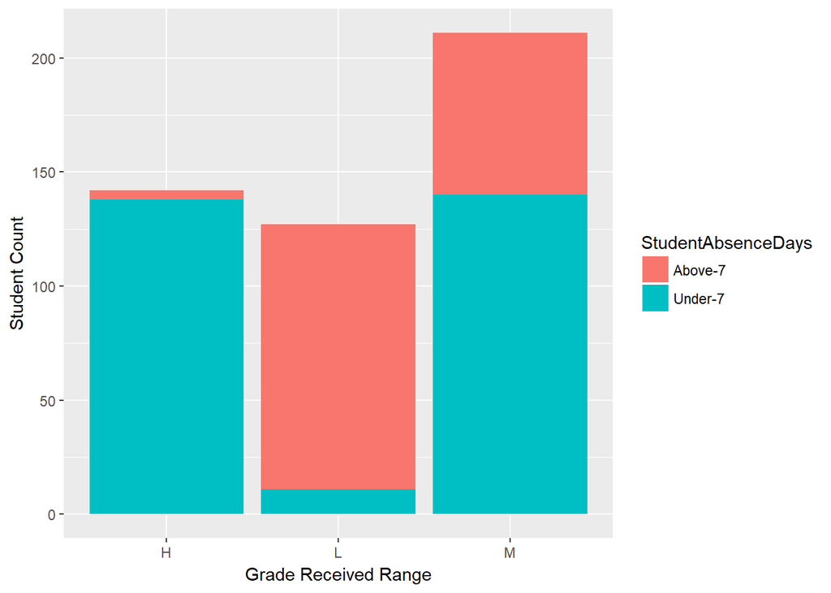

```r
ggplot(data = df, aes(x = GradeRange, fill = StudentAbsenceDays)) + geom_bar() +
    labs(x = "Grade Received Range", y = "Student Count")
```

Again, we see a clear correlation between the grade range and the number of days that student was absent. Essentially what we are trying to accomplish with these plots is develop a hypothesis that predicts which variables are the most significant in explaining the grade a student received. As of now we can only make an educated guess about which variables are significant, based on the data visualizations. Later on we will use concrete methods to do so.

We continue this process by creating a histogram of a student’s grade categorized by gender.

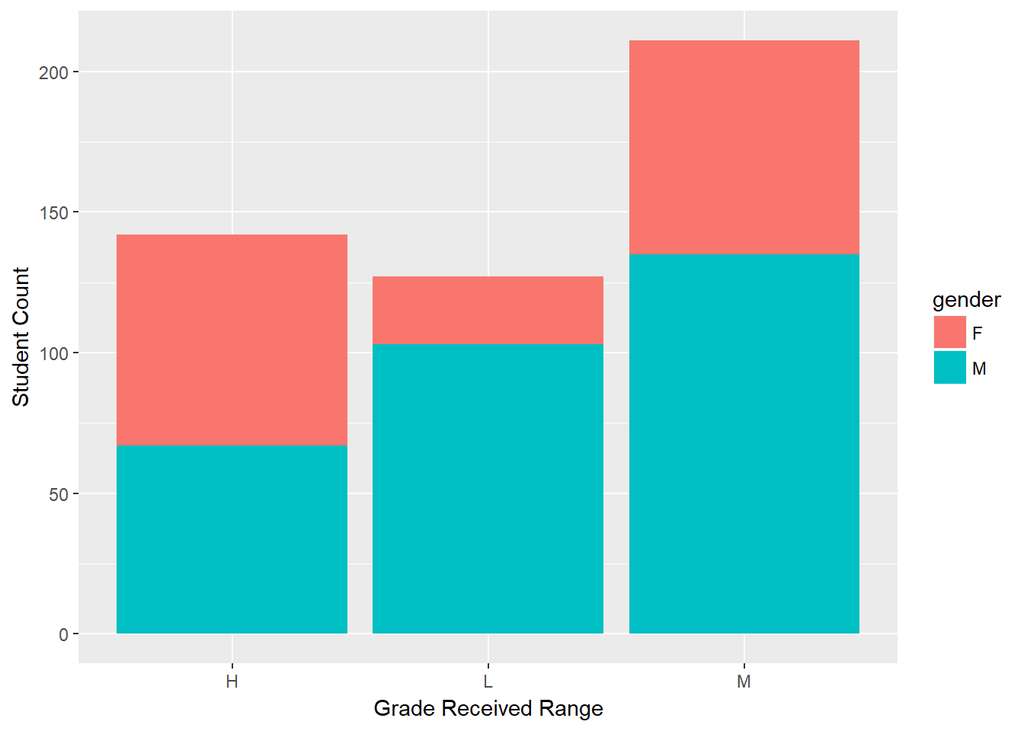

```r
ggplot(data = df, aes(x = GradeRange, fill = gender)) + geom_bar() +
    labs(x = "Grade Received Range", y = "Student Count")
```

The interpretation of this histogram isn’t as obvious as the previous ones but we can still learn some information from it. We see that many more female students are in the high and medium range than in the lower range. In contrast, we see that many more male students are in the lower and medium range than in the high grade range.

Next, we create a histogram of grade received categorized by their parent’s satisfaction with the school.

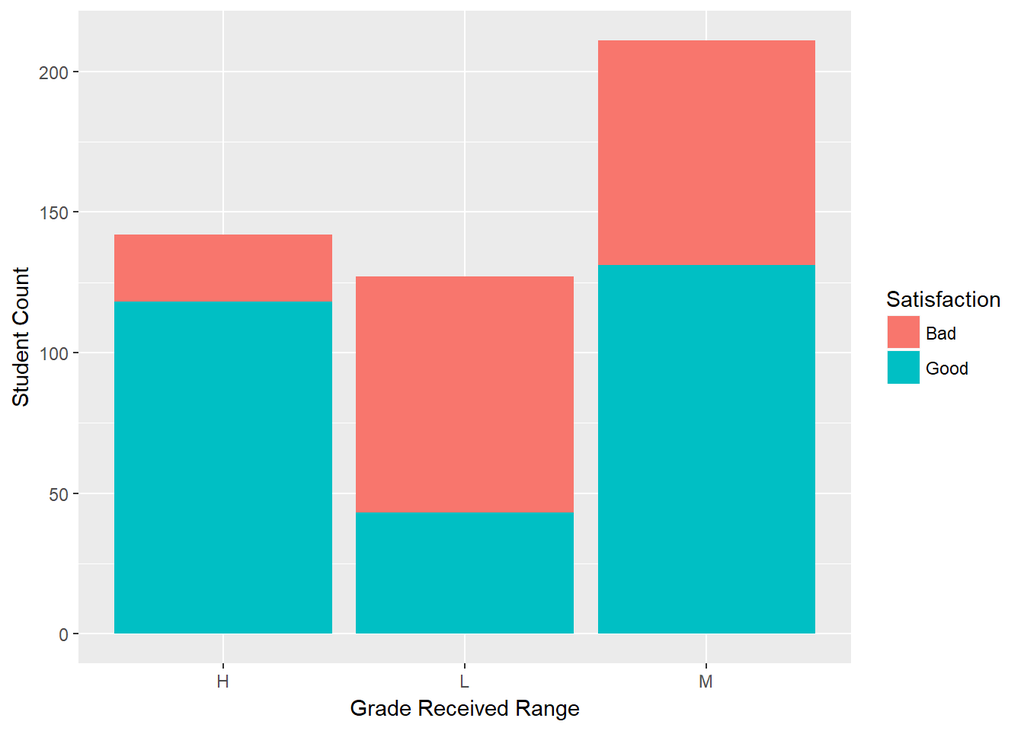

```r
ggplot(data = df, aes(x = GradeRange, fill = Satisfaction), title(main="Histogram of Grade Received by Relation")) + geom_bar() +
    labs(x = "Grade Received Range", y = "Student Count")
```

Again there is some correlation between the two variables.

#### **3.2 Pie Graphs**

Next we want to see the overall distribution of students in the different grade ranges. As we’d expect, most of the students fall in the 70-89 range while about the same number fall into the remaining ranges. We create this graph by first finding the sum of students in each range and creating a “slice” for each one.

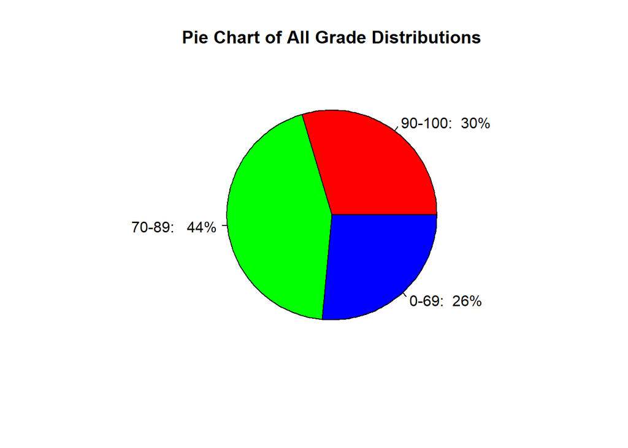

```r
numHigh <- sum(df$GradeRange == 'H')
numMedium <- sum(df$GradeRange == 'M')
numLow <- sum(df$GradeRange == 'L')
slices <- c(numHigh, numMedium, numLow)
lbls <- c("90-100: ", "70-89:  ","0-69: ")
pct <- round(slices/sum(slices)*100)
lbls <- paste(lbls, pct) # add percents to labels
lbls <- paste(lbls,"%",sep="") # ad % to labels
pie(slices,labels = lbls, col=rainbow(length(lbls)),
    main="Pie Chart of All Grade Distributions")
```

We can do the same thing for just female students. We filter out only female students in the dataset by using the filter function and specifying the filter criteria. Then we create the graph using the same method as above. You can read more about the filter function here: https://www.rdocumentation.org/packages/dplyr/versions/0.7.3/topics/filter

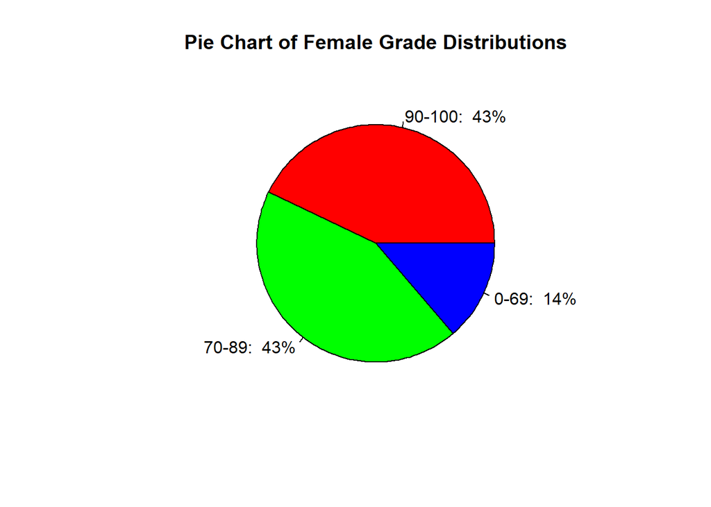

```r
female <- df %>%
  filter(gender=="F")
numHigh <- sum(female$GradeRange == 'H')
numMedium <- sum(female$GradeRange == 'M')
numLow <- sum(female$GradeRange == 'L')
slices <- c(numHigh, numMedium, numLow)
lbls <- c("90-100: ", "70-89: ","0-69: ")
pct <- round(slices/sum(slices)*100)
lbls <- paste(lbls, pct) # add percents to labels
lbls <- paste(lbls,"%",sep="") # ad % to labels
pie(slices,labels = lbls, col=rainbow(length(lbls)),
    main="Pie Chart of Female Grade Distributions")
```

This graph tells us that there are about the same number of female students in the high and medium grade ranges and a minority 14% in the low grade range. This confirms our data from the histogram.

We do the same for all male students and reach the same conclusion as from the histogram.

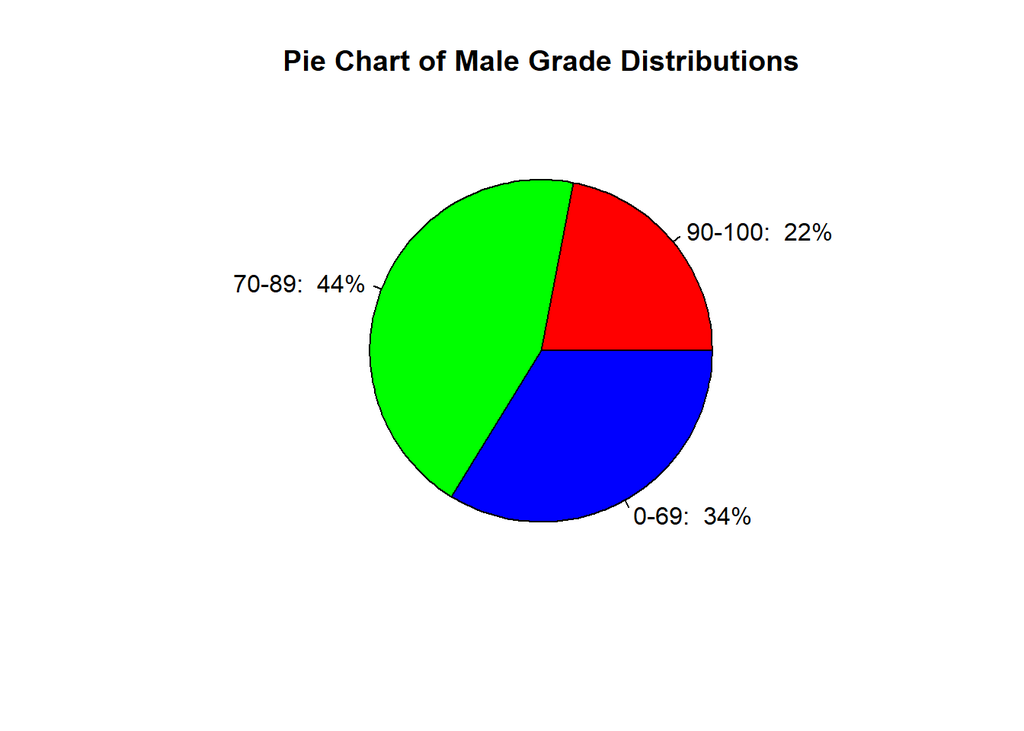

```r
male <- df %>%
  filter(gender=="M")
numHigh <- sum(male$GradeRange == 'H')
numMedium <- sum(male$GradeRange == 'M')
numLow <- sum(male$GradeRange == 'L')
slices <- c(numHigh, numMedium, numLow)
lbls <- c("90-100: ", "70-89: ","0-69: ")
pct <- round(slices/sum(slices)*100)
lbls <- paste(lbls, pct) # add percents to labels
lbls <- paste(lbls,"%",sep="") # ad % to labels
pie(slices,labels = lbls, col=rainbow(length(lbls)),
    main="Pie Chart of Male Grade Distributions")
```

#### **3.3 Violin and Box-and-Whisker Plots**

We will now look at a series of box-and-whisker and violin plots. These plots will help us visualize the overall distribution of our response variable, grade ranges, plotted against the numerical variables in our dataset. The first plot we will look at is raisedhands versus GradeRange. We will still be using ggplot for these plots.

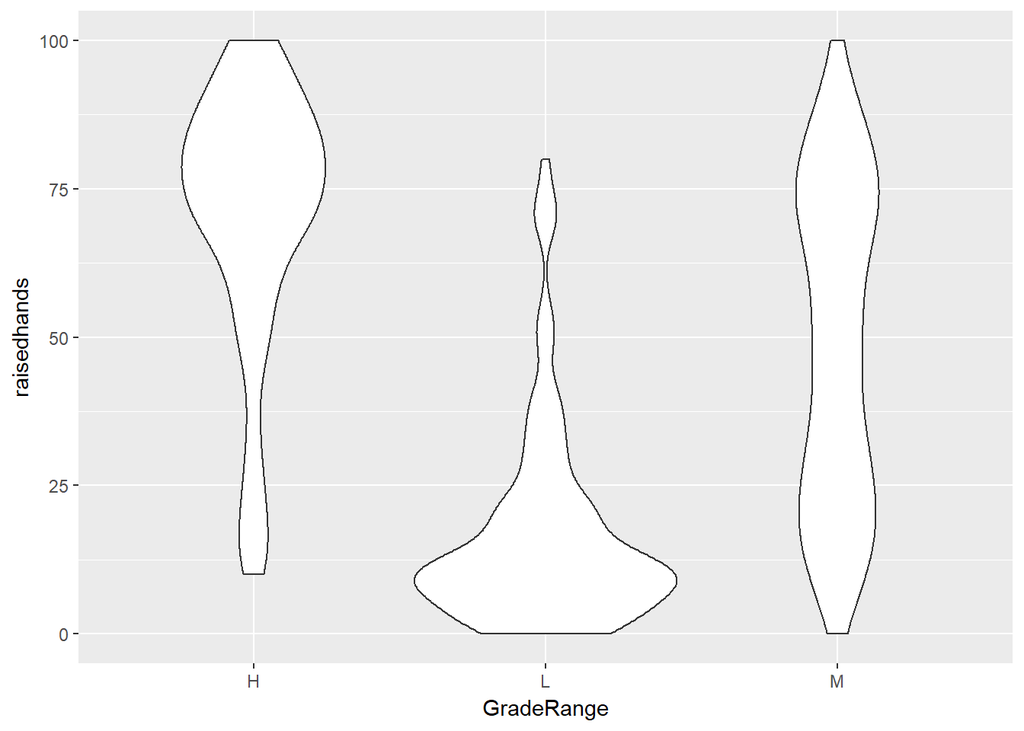

```r
ggplot(df, aes(x = GradeRange, y = raisedhands)) + geom_violin()
```

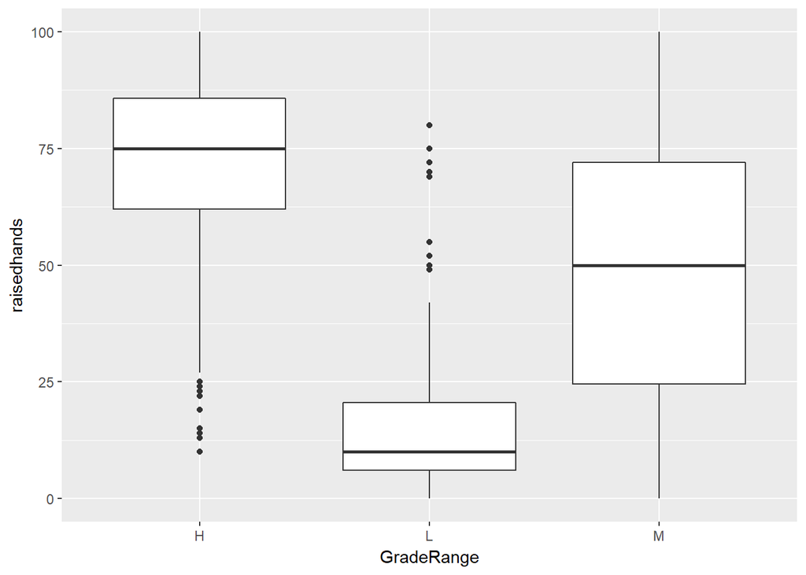

```r
ggplot(data = df, aes(x = GradeRange, y = raisedhands)) + geom_boxplot()
```

There are four major components of these two plots that can describe the distribution:

- Shape
  - We can see that the high and low grade ranges have long tails, indicating that there is some skew. The medium range is fairly balanced as should be expected.
- Center of Distribution
  - The high grade range is centered around high values of number of times a student raises his or her hand. The opposite is true for the low grade range. This means the mean of the high grade range is high whereas the mean of the low grade range is low (in terms of number of times a students raises his/her hand).
- Spread
  - All three ranges have a similar spread in terms of range. High and low ranges are obviously more concentrated in their perspective regions while medium is fairly evenly spread.
- Outliers
  - There are some outliers in both the high and low ranges which cause the mean and spread of these ranges to change.

Overall from this type of analysis, it is apparent that raisedhands is correlated to the grade a student receives.

We can do the same type of analysis or the remaining numerical variables. We will plot Resources versus GradeRange.

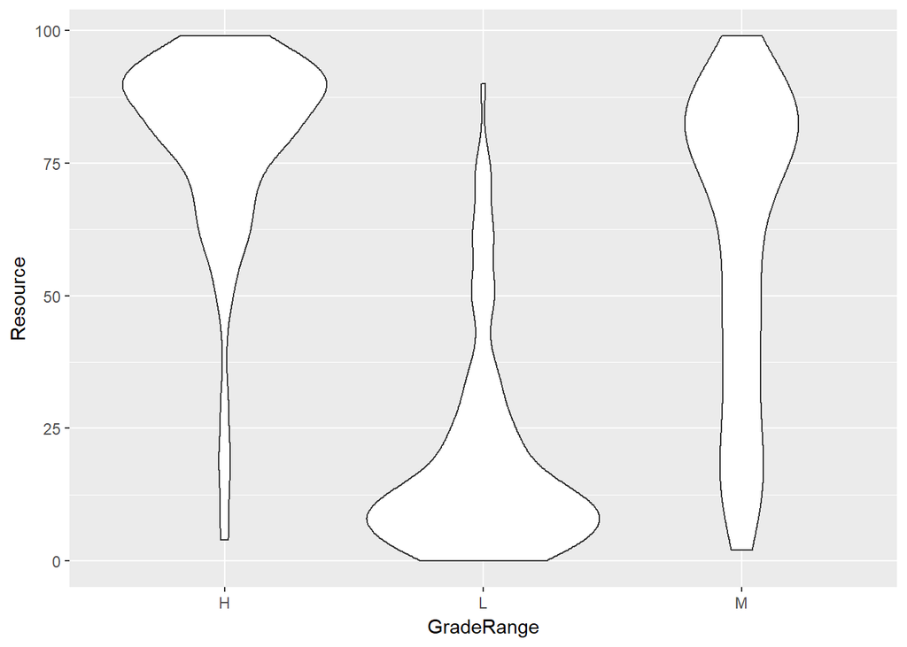

```r
ggplot(df, aes(x = GradeRange, y = Resource)) + geom_violin()
```

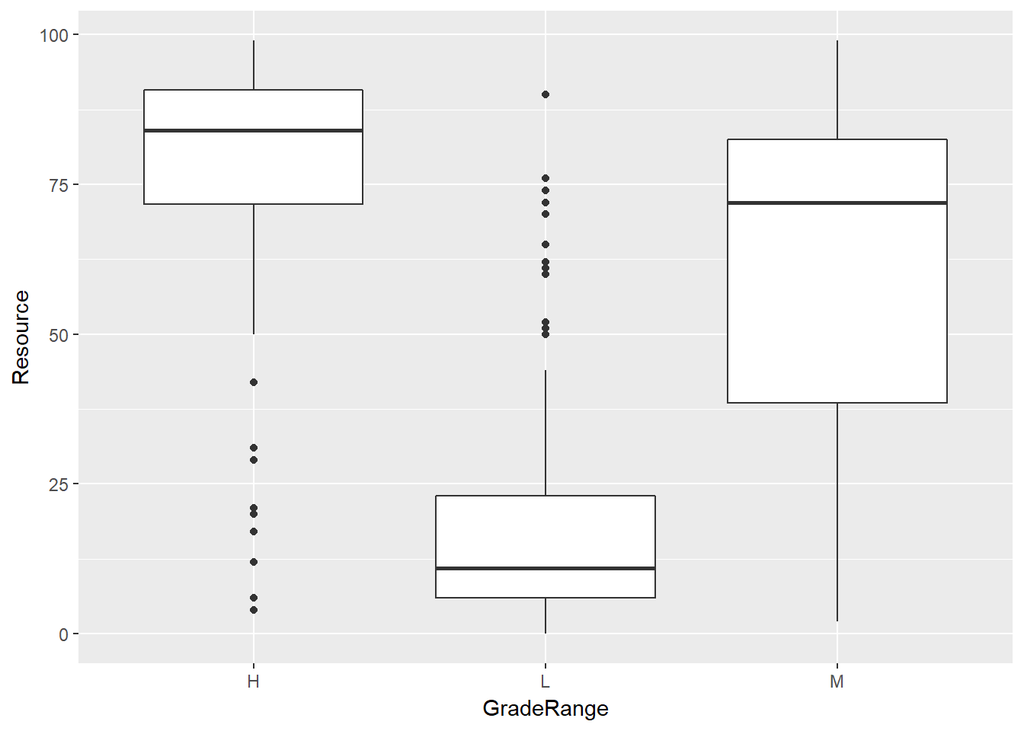

```r
ggplot(data = df, aes(x = GradeRange, y = Resource)) + geom_boxplot()
```

We come to the same conclusion as we did for raisedhands versus GradeRange.

The next plot will be for AnnouncementsView versus GradeRange.

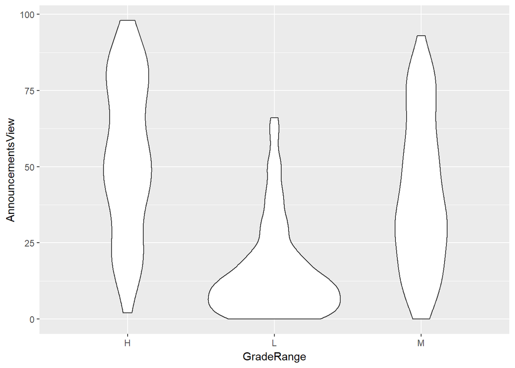

```r
ggplot(df, aes(x = GradeRange, y = AnnouncementsView)) + geom_violin()
```

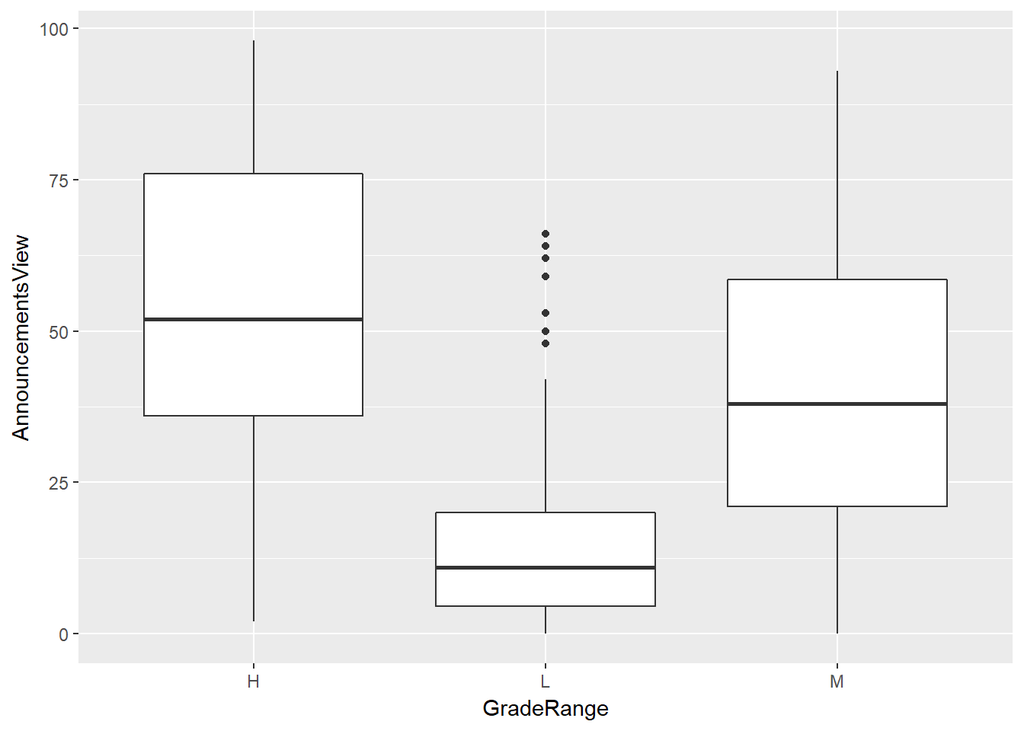

```r
ggplot(data = df, aes(x = GradeRange, y = AnnouncementsView)) + geom_boxplot()
```

We see that this plot is different than the other two. The low grade range is still concentrated towards the bottom of the plot but the high grade range is no longer concentrated towards the top. This is telling us that the number of times a student checks a new announcements results in the same number of students in the high grade range. This suggests that this variable might not be significant in our model later.

Finally, we plot Discussion versus GradeRange.

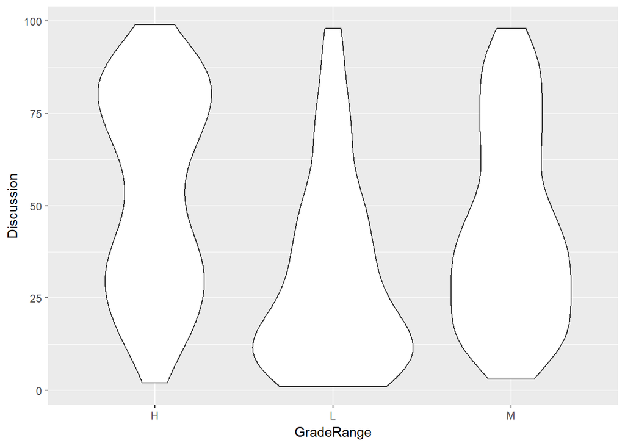

```r
ggplot(df, aes(x = GradeRange, y = Discussion)) + geom_violin()
```

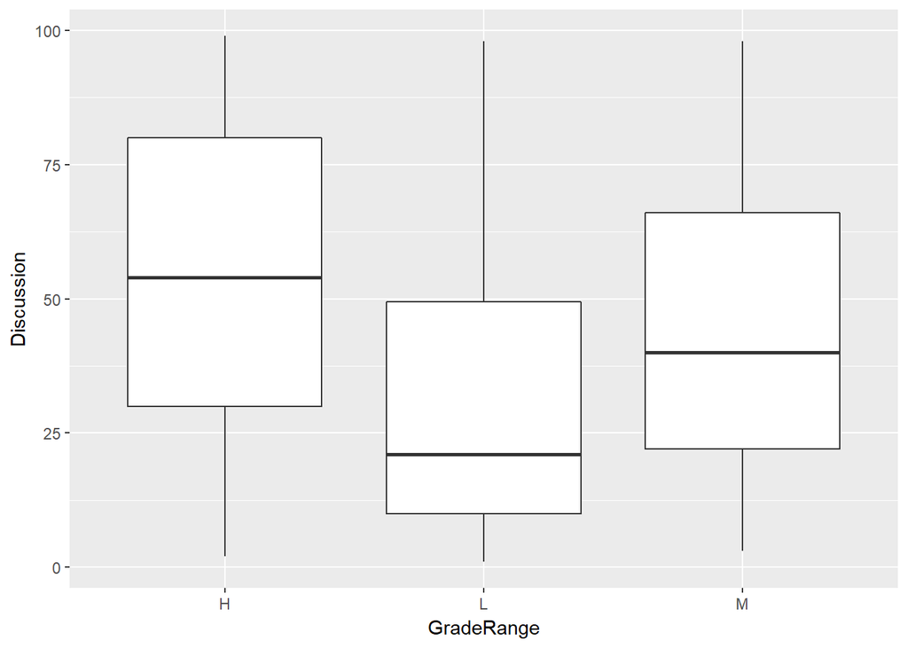

```r
ggplot(data = df, aes(x = GradeRange, y = Discussion)) + geom_boxplot()
```

From this plot we can see that there is no apparent correlation between Discussion and GradeRange as the distribution is relatively even compared to the previous plots.

For this dataset, the 2 most influential numeric predictors that seem to be correlated with a grade seem to be raisedhands and VisitedResources. The important categorical predictors seem to be gender, Satisfaction, and Absences. In the next step we will determine exactly which variables we want to use for our model through hypothesis testing.

### **4. Hypothesis Testing**

We are trying to decide which of the variables in our dataset are significant in explaining the response variable (GradeRange). We can do so through a process known as hypothesis testing. In this process, we set up a null and alternative hypothesis, and reject one of them based on the results of statistical analysis. There are multiple ways to set up this method, such as simple linear regression, multiple linear regression, logistic regression, etc. We will be using logistic regression for our dataset. This is becuse our response variable (GradeRanges) is categorical. If it were a numerical variable we would have used multiple linear regression.

#### **4.1 Initial Fit**

The first step is to create an initial fit, with all of the predictor variables present. Here we are using the multinom function from the nnet package in order to fit a regression model to our data. This is because our response variable has three values it can take on. If it were a binary categorical variable, we would have used the glm function. To read more about these functions, refer to these links: https://www.rdocumentation.org/packages/nnet/versions/7.3-12/topics/multinom, https://www.rdocumentation.org/packages/stats/versions/3.5.0/topics/glm

You can get a detailed guide on the functionality of multinomial logistic regression here: https://www.analyticsvidhya.com/blog/2016/02/multinomial-ordinal-logistic-regression/

Once we have done that, we must calculate the z statistic and p-value of the fitted model. These statistics help us to determine whether a given variable is significant in a fitted model. You can read more about logistic regression, p-values, and the z statistic here: https://en.wikipedia.org/wiki/Logistic_regression

```r
z <- summary(fit)$coefficients/summary(fit)$standard.errors
p <- (1 - pnorm(abs(z), 0, 1))*2

p
```

```
##    (Intercept) raisedhands Discussion AnnouncementsView     Resource
## L 3.021791e-06 0.001226478 0.01764986      0.0008094573 6.622021e-05
## M 1.028147e-05 0.012079733 0.09968617      0.6110268754 4.949252e-03
##     genderM SatisfactionGood  RelationMum StudentAbsenceDaysUnder-7
## L 0.0197244     8.628199e-05 3.466191e-03              4.440892e-16
## M 0.0838751     7.990143e-03 2.765944e-06              8.759015e-08
##   SubjectBiology SubjectChemistry SubjectEnglish SubjectFrench
## L     0.15663425        0.1470664       0.356691     0.1218064
## M     0.01123637        0.2118453       0.436815     0.1513762
##   SubjectGeology SubjectHistory SubjectIT SubjectMath SubjectQuran
## L      0.0000000      0.6254186 0.5481521 0.077866883    0.7798867
## M      0.2289852      0.3174595 0.7192680 0.003987826    0.2254087
##   SubjectScience SubjectSpanish SemesterS  YearG-04 YearG-05  YearG-06
## L      0.5718735      0.5045623 0.7936545 0.7971715        0 0.2258615
## M      0.8299040      0.3686206 0.1584149 0.4585273        0 0.1887501
##     YearG-07  YearG-08     YearG-09     YearG-10    YearG-11  YearG-12
## L 0.14151174 0.4075258 1.089019e-06 1.108302e-03 0.005738808 0.7497269
## M 0.00240527 0.2270456 3.121632e-06 3.620929e-07 0.036903749 0.3889453
##   NationalityIran NationalityIraq NationalityJordan NationalityKW
## L    1.318570e-02       0.0000000         0.9977829     0.9597425
## M    1.931557e-06       0.3240546         0.8903138     0.6068087
##   Nationalitylebanon NationalityLybia NationalityMorocco
## L          0.5537189                0          0.6471689
## M          0.6865802                0          0.5126762
##   NationalityPalestine NationalitySaudiArabia NationalitySyria
## L            0.0000000             0.00353900        0.6743479
## M            0.5250488             0.04544769        0.9340570
##   NationalityTunis NationalityUSA Nationalityvenzuela
## L        0.6945946      0.9187409                   0
## M        0.3889568      0.6497354                   0
```

#### **4.2 Hypothesis Test**

We can set up a hypothesis test to see which predictors are significant in explaining the response variable. The null hypothesis would be: $\beta_{1} = \beta_{2} = \beta_{3} = \beta_{4} = \beta_{5} = \beta_{6} = \beta_{7} = \beta_{8} = \beta_{9} = \beta_{10} = \beta_{11} = 0$  
versus the alternative which would be:

At least 1 $\beta \neq 0$

If we test at a 5% significance level, the variables Discussion, AnnouncementsView, genderM, Subject, and year should be removed from the model since their p-values are greater than 0.05. However, looking at our plots from before, we may still want to keep at least the genderM variables. For this reason we will test the at an 8% level of significance. While there are some nationality dummy variables that are significant, there are a lot more that are not. For the sake of simplicity, we will remove nationality from the model. Now, we can remove all the predictors other whose p-values are greater than 0.08.

Now that we have decided which variables can be removed from the model, we do exactly that and analyze the results.

```r
fit2 <- multinom(GradeRange ~ raisedhands + gender + Resource +  Satisfaction + Relation + StudentAbsenceDays, data=df)
z <- summary(fit2)$coefficients/summary(fit2)$standard.errors
p <- (1 - pnorm(abs(z), 0, 1))*2

p
```

```
##    (Intercept)  raisedhands    genderM     Resource SatisfactionGood
## L 0.000000e+00 2.531461e-06 0.02002506 1.007507e-07     0.0007085186
## M 4.041212e-14 1.113052e-04 0.09669626 1.787612e-02     0.0157641791
##    RelationMum StudentAbsenceDaysUnder-7
## L 8.533667e-02              0.000000e+00
## M 1.766797e-05              1.423865e-07
```

Notice that even now the gender variable is greater than the 8% threshold we had previously set. We will still leave it in the model since the p-value is listed for the medium range which we know did not have any correlation with almost any of the variables. Instead we will look at the p-value for the low ranges, which is less than 0.08.

We can now answer our original question, which was what factors effect a students’ academic performance. From our regression model, we conclude that the number of times a student raises his/her hand, gender, the number of times a student usess resources, how satisfied a students’ parent’s are with the school, the number of times a student is absent, and which parent is their primary caretaker are all significant in determining the academic performance of a student.

Our model is looking pretty good, but now it’s time to put it to test and see how well it predicts a students grade range given random values. We will do so in the next step.

### **5. Predictions and Comparisons**

In order to make predictions, we must first create a training dataframe and a testing dataframe. We do this by randomly splitting the original dataframe and assigning the random indices to the two new dataframes. The training dataframe is used to learn the model and the testing dataframe is used to test if the model predicts values correctly. Next we run the multinom function on the training set. Next, we make a prediction using our training set fitted model and the test set using the predict function. Finally, we calculate the mean of the error by comparing the predicted values to the actual values.

#### **5.1 Adjusted Logistic Regression Model**

We get the following result from running the steps above:

```r
test_indices <- sample(nrow(df), nrow(df)/2)
test_set <- df[test_indices,]
train_set <- df[-test_indices,]

logis_fit <- multinom(GradeRange ~ raisedhands + Discussion + Resource + gender + Satisfaction + Relation + StudentAbsenceDays, data=train_set)
logis_pred <- predict(logis_fit,test_set,type="probs")
predicted_class <- predict (logis_fit, test_set)

table(predicted_class, test_set$GradeRange)
```

```
##
## predicted_class  H  L  M
##               H 57  0 19
##               L  0 52 10
##               M 19  8 75
```

```r
mean(as.character(predicted_class) != as.character(test_set$GradeRange))
```

```
## [1] 0.2333333
```

#### **5.2 Decision Tree**

We do this by using the tree function from the tree package. You can read more about the functions in the tree package here: https://www.rdocumentation.org/packages/tree/versions/1.0-39 . The tree function creates a tree by binary recursive partitioning using the response in the specified formula and choosing splits from the terms of the right hand side of the “~”.

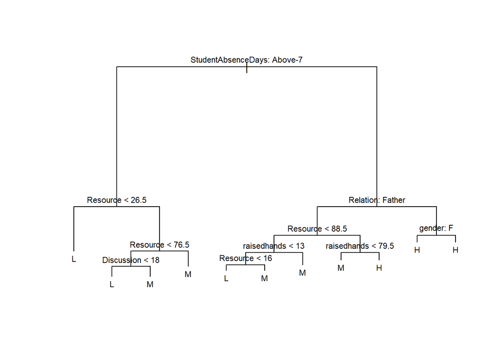

```r
tree <- tree(GradeRange~raisedhands + Discussion + Resource + gender + Satisfaction + Relation + StudentAbsenceDays, data=df)
plot(tree)
text(tree, pretty=0, cex=0.7)
```

You read this tree as follows: If the condition of the current node is true go left else go right. For example, if StudentAbsenceDay > 7 move to the left branch else move to the right branch. Continue this process until you reach a lead node with a value for GradeRange.

#### **5.3 Cross-Validation**

Now that we have created our decision tree model, we want to compare it to the logistic regression model and see which one has a higher percentage of accuracy. We will do so using a method known as k-fold cross validation. This entails partitioning the observations into k-folds (70 in our case) and then for each of the k groups of observations, we train a model based on the other k-1 folds. Finally we estimate the test-set error and compute the average error across each fold in order to determine the accuracy for each model. For this method, we will create a test and training dataframe, as we did for the logistic regression model prediction. First, we run a logistic fit on the training set using the multinom function. Then we make a prediction (predict function) for the test set using the model we created using the training set. Finally we calculate the mean error for each fold. We repeat the same process for the decision tree model and then return the two mean errors, one for each model.

```r
fold_indices <- cvFolds(n=nrow(df), K=70)

error_rates <- sapply(1:10, function(fold_index) {
  test_indices <- which(fold_indices$which == fold_index)
  test_set <- df[test_indices,]
  train_set <- df[-test_indices,]

  logis_fit <- multinom(GradeRange ~ raisedhands + Discussion + Resource + gender + Satisfaction + Relation + StudentAbsenceDays, data=train_set)

  logis_pred <- predict(logis_fit,test_set,type="probs")
  predicted_class <- predict (logis_fit, test_set)

  table(predicted_class, test_set$GradeRange)
  logis_error <- mean(as.character(predicted_class) != as.character(test_set$GradeRange))

  tree_fit <- tree(GradeRange ~ raisedhands + +Discussion + Resource + gender + Satisfaction + Relation + StudentAbsenceDays, data=train_set)
  pruned_tree <- prune.tree(tree_fit, best=3)

  tree_pred <- predict(pruned_tree, newdata=test_set, type="class")
  tree_error <- mean(test_set$GradeRange != tree_pred)
  c(logis_error, tree_error)
  })
rownames(error_rates) <- c("logis", "tree")
error_rates <- as.data.frame(t(error_rates))

error_rates <- error_rates %>%
  mutate(fold=1:n()) %>%
  gather(method,error,-fold)

error_rates %>%
  head(50) %>%
  knitr::kable("html")
```

| fold | method | error |
| --- | --- | --- |
| 1 | logis | 0.4285714 |
| 2 | logis | 0.1428571 |
| 3 | logis | 0.0000000 |
| 4 | logis | 0.1428571 |
| 5 | logis | 0.1428571 |
| 6 | logis | 0.1428571 |
| 7 | logis | 0.0000000 |
| 8 | logis | 0.1428571 |
| 9 | logis | 0.2857143 |
| 10 | logis | 0.1428571 |
| 1 | tree | 0.5714286 |
| 2 | tree | 0.4285714 |
| 3 | tree | 0.2857143 |
| 4 | tree | 0.2857143 |
| 5 | tree | 0.4285714 |
| 6 | tree | 0.4285714 |
| 7 | tree | 0.2857143 |
| 8 | tree | 0.4285714 |
| 9 | tree | 0.4285714 |
| 10 | tree | 0.2857143 |

As we can see from this output, the logistic fit model seems to have a lower error, on average, than the decision tree model. We can test to see if this is true by plotting the mean errors:

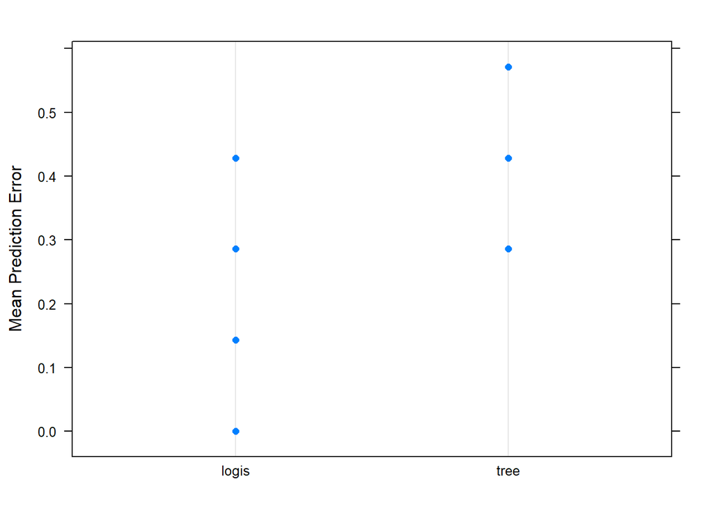

```r
dotplot(error~method, data=error_rates, ylab="Mean Prediction Error")
```

As we can see from the plot above, the mean prediction error appears to be higher on average for the decision tree model. We can fit a linear regression function to the mean errors to see what the slope looks like for each of the models. We do this by using the lm function. You can read more about the lm function here: https://www.rdocumentation.org/packages/stats/versions/3.5.0/topics/lm

```r
lm(error~method, data=error_rates) %>%
  tidy() %>%
  knitr::kable()
```

| term | estimate | std.error | statistic | p.value |
| --- | --- | --- | --- | --- |
| (Intercept) | 0.1571429 | 0.0353152 | 4.449719 | 0.0003095 |
| methodtree | 0.2285714 | 0.0499433 | 4.576620 | 0.0002340 |

Looking at the output of this regression fit, the tree method has a standard error of 0.0499 where as the logistic regression model has a standard error of 0.0353. Based on these outputs, we can conclude that the logistic regression model is more accurate in predicting the correct GradeRange of a student.

#### **5.4 Random Forest**

The final method that we will look at is known as a random forest, which is another tree based method. In this method, we resample the training data with the hope of improving prediction performance and reducing instability and variability (which occurs with decision trees) by averaging multiple decision trees. In this method, we reduce the correlation between trees in a forest by recursively partitioning a randomly selected subset of predictors to check for the best split. We will be using the randomForest function from the randomForest package, which you can read more about here: https://www.rdocumentation.org/packages/randomForest/versions/4.6-14/topics/randomForest Again, we create test and training set to train and predict using the trained model.

```r
set.seed(1234)

test_indices <- sample(nrow(df), nrow(df)/2)
test_set <- df[test_indices,]
train_set <- df[-test_indices,]

rf <- randomForest(GradeRange~raisedhands + +Discussion + Resource + gender + Satisfaction + Relation + StudentAbsenceDays, data=train_set, ntree=5000, nodes = 20)

rf.predict <- predict(rf, test_set)
confusionMatrix(test_set$GradeRange, rf.predict)
```

```
## Confusion Matrix and Statistics
##
##           Reference
## Prediction  H  L  M
##          H 54  0 23
##          L  0 50  9
##          M  9  8 87
##
## Overall Statistics
##
##                Accuracy : 0.7958
##                  95% CI : (0.7392, 0.845)
##     No Information Rate : 0.4958
##     P-Value [Acc > NIR] : < 2.2e-16
##
##                   Kappa : 0.6817
##  Mcnemar's Test P-Value : NA
##
## Statistics by Class:
##
##                      Class: H Class: L Class: M
## Sensitivity            0.8571   0.8621   0.7311
## Specificity            0.8701   0.9505   0.8595
## Pos Pred Value         0.7013   0.8475   0.8365
## Neg Pred Value         0.9448   0.9558   0.7647
## Prevalence             0.2625   0.2417   0.4958
## Detection Rate         0.2250   0.2083   0.3625
## Detection Prevalence   0.3208   0.2458   0.4333
## Balanced Accuracy      0.8636   0.9063   0.7953
```

### **6. Conclusions**

Knowing which factors can affect a students’ academic performance is important for both students and their parents. From this tutorial, we saw the power of data science and machine learning, as it helps us determine important factors and helps us predict future events. From our analysis and modelling, we now the number of times a student raises his/her hand, gender, the number of times a student usess resources, how satisfied a students’ parent’s are with the school, the number of times a student is absent, and which parent is their primary caretaker are all important factors in determining a students’ academic performance. We can ask and test even more interesting questions for this dataset such as how nationality and gender might effect how engaged a student is in the classroom. Perhaps we would be able to determine even more information from this dataset if it had observed some different attributes such as hours spent studying and number of extracurriculars taken.